# Motor Trend: Trasmission & MPG

Riccardo Del Signore

2025-08-31

# 1 MOTOR TREND analysis

## 1.1 Data & Methods

- Dataset: mtcars
- Outcome: mpg
- Potential confounders: wt, hp , cyl, disp, gear, carb

## 1.2 Exploratorty Data Analysis (EDA)

- Descriptive statistics

```r
# summary stats of group per am

mt %>%
  group_by(am) %>%
  summarise(
    n = n(),
    mean_mpg = mean(mpg),
    sd_mpg = sd(mpg),
    mean_wt = mean(wt),
    sd_wt = sd(wt),
    mean_hp = mean(hp),
    sd_hp = sd(hp),
    mean_cyl = mean(cyl),
    sd_cyl = sd(cyl)
  )
```

```
## # A tibble: 2 × 10
##   am            n mean_mpg sd_mpg mean_wt sd_wt mean_hp sd_hp mean_cyl sd_cyl
##   <fct>     <int>    <dbl>  <dbl>   <dbl> <dbl>   <dbl> <dbl>    <dbl>  <dbl>
## 1 Automatic    19     17.1   3.83    3.77 0.777    160.  53.9     6.95   1.54
## 2 Manual       13     24.4   6.17    2.41 0.617    127.  84.1     5.08   1.55
```

- Boxplot MPG vs trasmissionn type

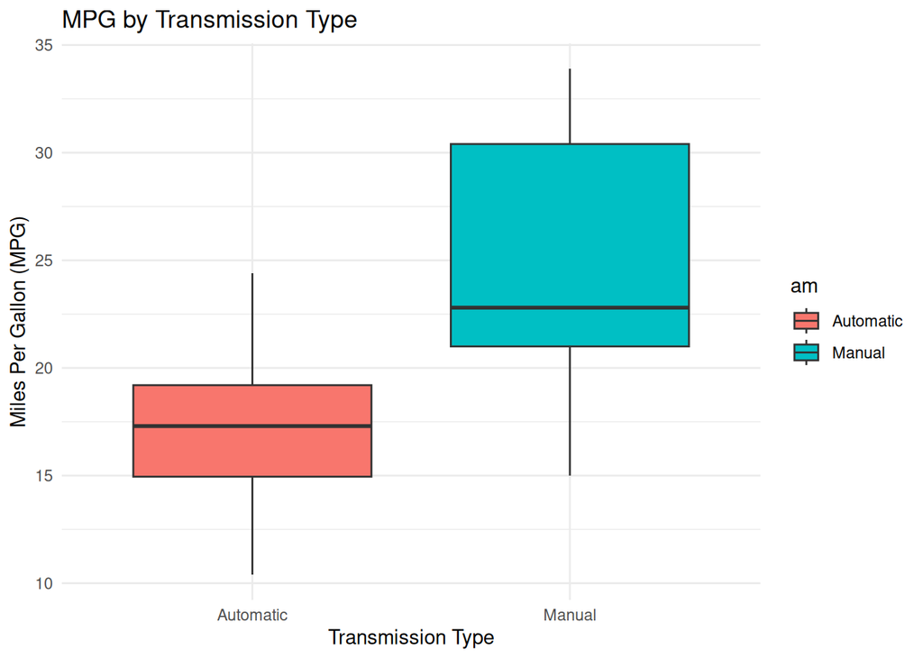

```r
ggplot(mt, aes(x = am, y = mpg, fill = am)) +
  geom_boxplot() +
  labs(title = "MPG by Transmission Type",
       x = "Transmission Type",
       y = "Miles Per Gallon (MPG)") +
  theme_minimal()
```

Figure 1 shows a clear separation between groups: manual cars tend to have higher MPG values and more variability compared with automatic cars.

- Scatter Plot MPG vs wt

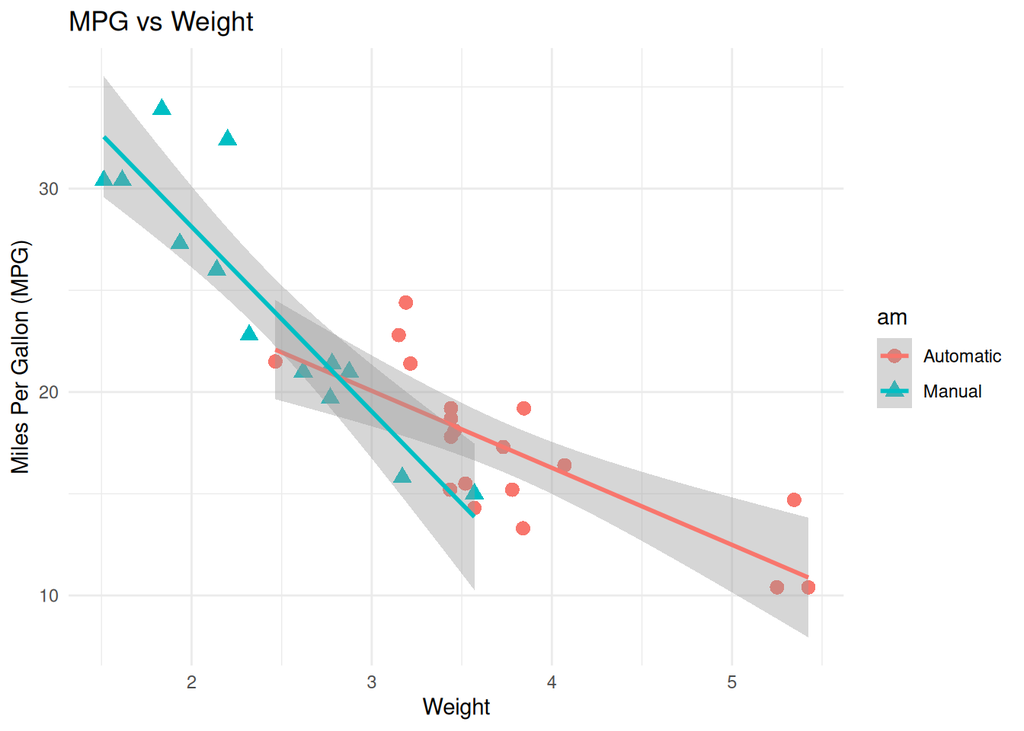

```r
ggplot(mt, aes(x = wt, y = mpg, color = am, shape = am)) +
  geom_point(size = 3) +
  geom_smooth(method = "lm", se = TRUE) +
  labs(title = "MPG vs Weight",
       x = "Weight",
       y = "Miles Per Gallon (MPG)") +
  theme_minimal()
```

Figure 2 suggests that the weight is strongly associated with fuel efficiency: heavier cars have a lower MPG. Manual cars are generally lighter, which may partly explain their higher fuel efficiency. This could suggest the need for adjusted models controlling weight as a confounder